# Graphics Project

## I. Introduction

## II. Description of the data source

After considering potential influencing factors of diabetes, we are both responsible for collecting data in terms of different factors. Data are all from the original sources and mostly from “Centers for Disease Control and Prevention” and “Bureau of Economic Analysis” from U.S. Department of Commerce. In the form of getting the data, we either directly downloaded excels (or csv) or scraped data from the web pages.

For physical indicators, High Cholesterol, Hypertension, Inactivity, Obesity, Poor Health and Smoking are counted.

Since education will enhance one’s self-management ability and enrich scientific knowledges so that we wonder if education levels would be a factor and how much it will be related to diabetes. Education levels are specified by three types including under high school, high school and post high school. Each state will have a percentage of diabete rates corresponding to each education levels.

In order to consider diet habits that affacting diabetes, we took sweet beverage consumption among adults and the number of McDonald’s location among states as metrices. Unfortunately, we are only able to obtain data of the first kind (sweet beverage consumption) from 24 states.

Alcohol is a kind of popular lifestyle in US which let us to think about whether excessive alcohol consumption is one of major factor causing diabetes in the long run.

Moreover, Per capita GDP is also important indicator for representing economic condition of each state, which might potentially affacts the chance of being diabetes.

#### Reference

https://gis.cdc.gov/grasp/diabetes/DiabetesAtlas.html  
https://www.statista.com/statistics/631235/number-of-mcdonald-s-us-by-state/  
https://www.cdc.gov/alcohol/data-stats.htm  
https://www.cdc.gov/mmwr/volumes/65/wr/mm6507a1.htm  
https://apps.bea.gov/itable/iTable.cfm?ReqID=70&step=1#reqid=70&step=1&isuri=1

## III. Description of data import / cleaning / transformation

For the parts of data that directly downloading excel or csv from orginial websites, we used read.csv() to import into R for further data processing. Those data are including High Cholesterol, Hypertension, Inactivity, Obesity, Poor Health, Smoking, age, education, per capita GDP and number of McDonald’s location.

On the other part of data that does not have nice downloadable excel or csv, we used packages tidyverse and rvest to scrap tables from webpages and saved those tables into our .data/raw in .csv format. Those data include alcohol and sweet beverage consumption. In alcohol data frame, we renamed each column as Location, Total Cost, Cost Per Drink, Cost Per Capital respectively. In sweet beverage consumption data frame, we scraped two tables from one web page. After we checked each list item, it turns out that the tables we want are the second and third list elements: one is sweetened beverage consumption that are further specified by different ages, genders, races; the other is sweetened beverage consumption that are further specified by different employment status and education levels. Column names are taken into consideration to define each variable, and we removed the rows we don’t need. All numeric related data are cleaned from character form to numeric or integer form for being ready to later analysis.

#### Scraping data from webpages

#### Read in Raw Data

#### Basic Data Cleaning

## IV. Analysis of missing values

Do we have missing values for datasets that involving all the variables?

```
##           State HighCholesterol    Hypertension      Inactivity
##               0               1               1               1
##             Num         Obesity     Poor_Health         Smoking
##               1               1               1               3
##           18-44           45-64           65-74             75+
##               2               1               1               1
## UnderHighSchool      HighSchool     HighSchool+      NoSweetBev
##               1               1               1              31
##     less1perDay     more1perDay            Rank        McNumber
##              31              31               5               5
```

```
##  [1]  3  2  0  3  0  3  0  3  2  3  3  5  3  3  3  0  0  0  0  0  3  0  3
## [24]  5  3  0  0  3  3  0  4  3  0  3  0  0  3  0  0  3  3  5  3  0  3  3
## [47]  3  0  0 19  3  3  0  0  3
```

```
##           State HighCholesterol    Hypertension      Inactivity
##      0.00000000      0.01818182      0.01818182      0.01818182
##             Num         Obesity     Poor_Health         Smoking
##      0.01818182      0.01818182      0.01818182      0.05454545
##           18-44           45-64           65-74             75+
##      0.03636364      0.01818182      0.01818182      0.01818182
## UnderHighSchool      HighSchool     HighSchool+      NoSweetBev
##      0.01818182      0.01818182      0.01818182      0.56363636
##     less1perDay     more1perDay            Rank        McNumber
##      0.56363636      0.56363636      0.09090909      0.09090909
```

```
##  [1] 0.15 0.10 0.00 0.15 0.00 0.15 0.00 0.15 0.10 0.15 0.15 0.25 0.15 0.15
## [15] 0.15 0.00 0.00 0.00 0.00 0.00 0.15 0.00 0.15 0.25 0.15 0.00 0.00 0.15
## [29] 0.15 0.00 0.20 0.15 0.00 0.15 0.00 0.00 0.15 0.00 0.00 0.15 0.15 0.25
## [43] 0.15 0.00 0.15 0.15 0.15 0.00 0.00 0.95 0.15 0.15 0.00 0.00 0.15
```

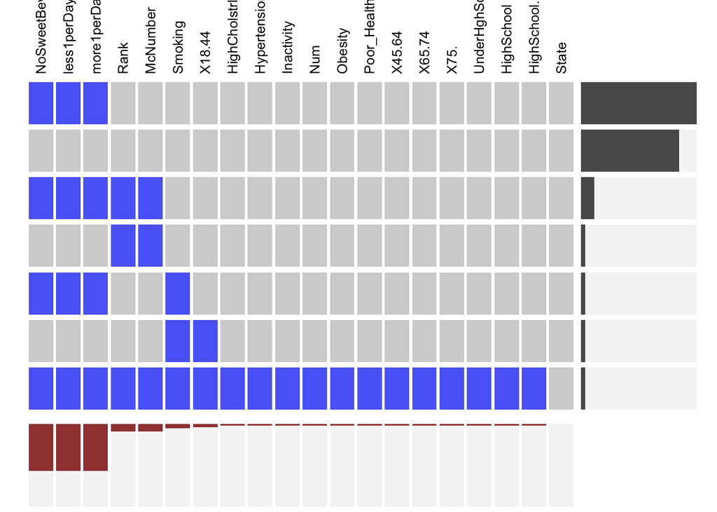

[output not shown]

[output cut: 55 more lines]

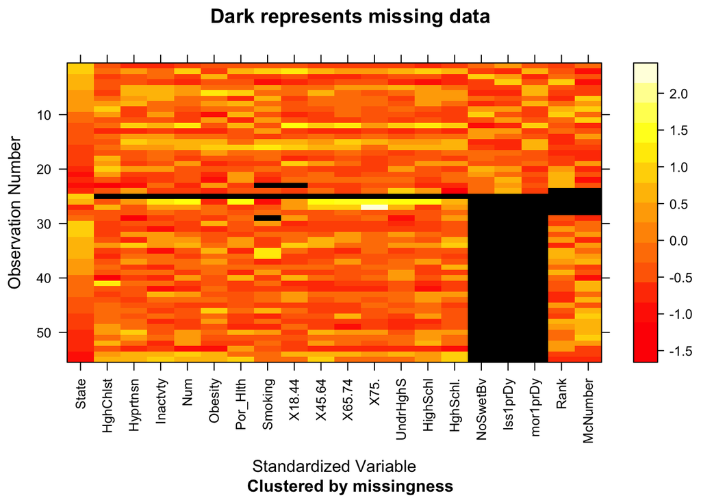

**Dealing with missing values**

### Minor Risk Factors

**Dot Plots(Facet-wrap)**

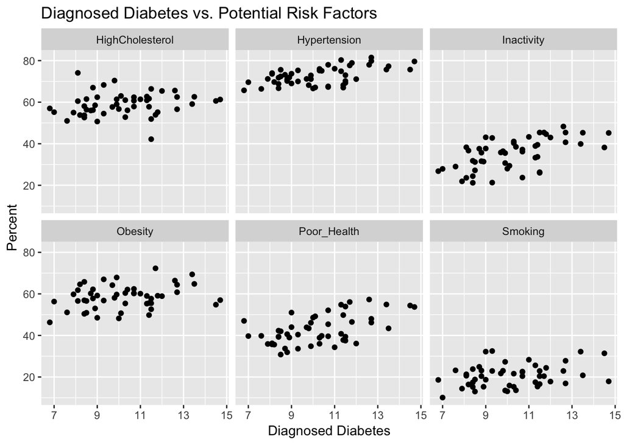

**Parallel Coordinates Plot**

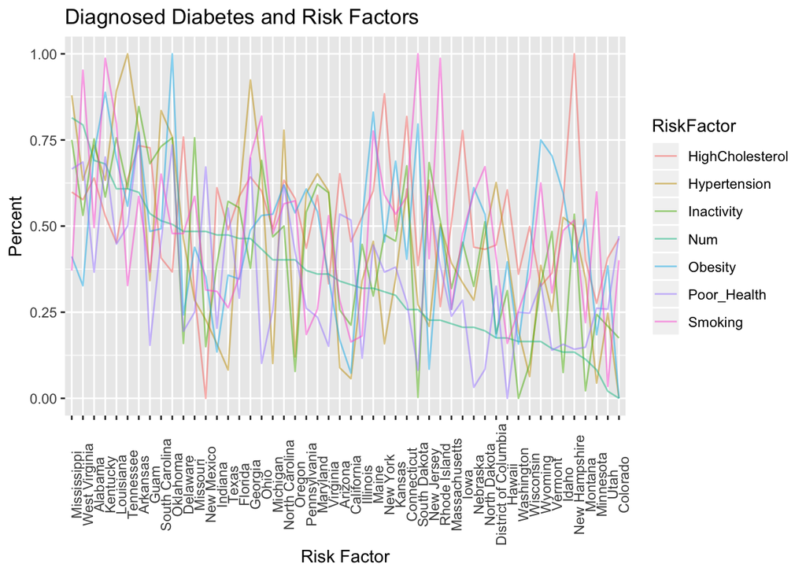